# Project: Investigate a Dataset (Medical Appointments No Shows in Brazil)

August 27, 2021

# Content

- Introduction & Data Description
- Data Wrangling
- Questions
- Exploratory Data Analysis
- Conclusion

# Introduction

I have joined Udicity Scholarship. I have to do some work to apply what I have learnt in the content of course as a tangible application to use Python programming code,statistics, visualizations that will help in illustrating relations between attributes & answering to questions Using descriptive statistics, So I decide to investigate No show appointment dataset to translate all effort in my previous study to valuable work.

# Data Description

The attached in README.pdf file there is a table contains description for column names & types.

# Data Wrangling

```python
import numpy as np
import pandas as pd
import matplotlib.pyplot as plt
import seaborn as sns
%matplotlib inline
```

```python
#After importing the required libraries I have to loaad the csv file containing data
#NSA_DF,,,,,, Is for no show appointment datafram
NSA_DF = pd.read_csv('E:udicty\\Project (2)\\noshowappointments-kagglev2-may-2016.csv')
```

```python
NSA_DF
```

|  | PatientId | AppointmentID | Gender | ScheduledDay | AppointmentDay | Age | Neighbourhood | Scholarship | Hipertension | Diabetes | Alcoholism | Handcap | SMS_received | No-show |
| --- | --- | --- | --- | --- | --- | --- | --- | --- | --- | --- | --- | --- | --- | --- |
| 0 | 2.987250e+13 | 5642903 | F | 2016-04-29T18:38:08Z | 2016-04-29T00:00:00Z | 62 | JARDIM DA PENHA | 0 | 1 | 0 | 0 | 0 | 0 | No |
| 1 | 5.589978e+14 | 5642503 | M | 2016-04-29T16:08:27Z | 2016-04-29T00:00:00Z | 56 | JARDIM DA PENHA | 0 | 0 | 0 | 0 | 0 | 0 | No |
| 2 | 4.262962e+12 | 5642549 | F | 2016-04-29T16:19:04Z | 2016-04-29T00:00:00Z | 62 | MATA DA PRAIA | 0 | 0 | 0 | 0 | 0 | 0 | No |
| 3 | 8.679512e+11 | 5642828 | F | 2016-04-29T17:29:31Z | 2016-04-29T00:00:00Z | 8 | PONTAL DE CAMBURI | 0 | 0 | 0 | 0 | 0 | 0 | No |
| 4 | 8.841186e+12 | 5642494 | F | 2016-04-29T16:07:23Z | 2016-04-29T00:00:00Z | 56 | JARDIM DA PENHA | 0 | 1 | 1 | 0 | 0 | 0 | No |
| ... | ... | ... | ... | ... | ... | ... | ... | ... | ... | ... | ... | ... | ... | ... |
| 110522 | 2.572134e+12 | 5651768 | F | 2016-05-03T09:15:35Z | 2016-06-07T00:00:00Z | 56 | MARIA ORTIZ | 0 | 0 | 0 | 0 | 0 | 1 | No |
| 110523 | 3.596266e+12 | 5650093 | F | 2016-05-03T07:27:33Z | 2016-06-07T00:00:00Z | 51 | MARIA ORTIZ | 0 | 0 | 0 | 0 | 0 | 1 | No |
| 110524 | 1.557663e+13 | 5630692 | F | 2016-04-27T16:03:52Z | 2016-06-07T00:00:00Z | 21 | MARIA ORTIZ | 0 | 0 | 0 | 0 | 0 | 1 | No |
| 110525 | 9.213493e+13 | 5630323 | F | 2016-04-27T15:09:23Z | 2016-06-07T00:00:00Z | 38 | MARIA ORTIZ | 0 | 0 | 0 | 0 | 0 | 1 | No |
| 110526 | 3.775115e+14 | 5629448 | F | 2016-04-27T13:30:56Z | 2016-06-07T00:00:00Z | 54 | MARIA ORTIZ | 0 | 0 | 0 | 0 | 0 | 1 | No |

110527 rows × 14 columns

```python
#Dataframe shape (Rows * Columns)& variable types
print(NSA_DF.shape)
print("-*-"*40)
print(NSA_DF.dtypes)
print("-*-"*40)
```

```
(110527, 14)
-*--*--*--*--*--*--*--*--*--*--*--*--*--*--*--*--*--*--*--*--*--*--*--*--*--*--*--*--*--*--*--*--*--*--*--*--*--*--*--*-
PatientId         float64
AppointmentID       int64
Gender             object
ScheduledDay       object
AppointmentDay     object
Age                 int64
Neighbourhood      object
Scholarship         int64
Hipertension        int64
Diabetes            int64
Alcoholism          int64
Handcap             int64
SMS_received        int64
No-show            object
dtype: object
-*--*--*--*--*--*--*--*--*--*--*--*--*--*--*--*--*--*--*--*--*--*--*--*--*--*--*--*--*--*--*--*--*--*--*--*--*--*--*--*-
```

```python
#In order to view the column names using for loop:
for col in NSA_DF.columns:
    col_name = []
    col_name.append(col)
    print(col_name)
```

```
['PatientId']
['AppointmentID']
['Gender']
['ScheduledDay']
['AppointmentDay']
['Age']
['Neighbourhood']
['Scholarship']
['Hipertension']
['Diabetes']
['Alcoholism']
['Handcap']
['SMS_received']
['No-show']
```

```python
#inspecting exsitance of null & missing values values
NSA_DF.info()
print('-*-'*40)
print(NSA_DF.isnull().sum())
```

```
<class 'pandas.core.frame.DataFrame'>
RangeIndex: 110527 entries, 0 to 110526
Data columns (total 14 columns):
 #   Column          Non-Null Count   Dtype
---  ------          --------------   -----
 0   PatientId       110527 non-null  float64
 1   AppointmentID   110527 non-null  int64
 2   Gender          110527 non-null  object
 3   ScheduledDay    110527 non-null  object
 4   AppointmentDay  110527 non-null  object
 5   Age             110527 non-null  int64
 6   Neighbourhood   110527 non-null  object
 7   Scholarship     110527 non-null  int64
 8   Hipertension    110527 non-null  int64
 9   Diabetes        110527 non-null  int64
 10  Alcoholism      110527 non-null  int64
 11  Handcap         110527 non-null  int64
 12  SMS_received    110527 non-null  int64
 13  No-show         110527 non-null  object
dtypes: float64(1), int64(8), object(5)
memory usage: 11.8+ MB
-*--*--*--*--*--*--*--*--*--*--*--*--*--*--*--*--*--*--*--*--*--*--*--*--*--*--*--*--*--*--*--*--*--*--*--*--*--*--*--*-
PatientId         0
AppointmentID     0
Gender            0
ScheduledDay      0
AppointmentDay    0
Age               0
Neighbourhood     0
Scholarship       0
Hipertension      0
Diabetes          0
Alcoholism        0
Handcap           0
SMS_received      0
No-show           0
dtype: int64
```

there is no null or missing values in the dataframe

```python
# Descripping the data
NSA_DF.describe()
```

|  | PatientId | AppointmentID | Age | Scholarship | Hipertension | Diabetes | Alcoholism | Handcap | SMS_received |
| --- | --- | --- | --- | --- | --- | --- | --- | --- | --- |
| count | 1.105270e+05 | 1.105270e+05 | 110527.000000 | 110527.000000 | 110527.000000 | 110527.000000 | 110527.000000 | 110527.000000 | 110527.000000 |
| mean | 1.474963e+14 | 5.675305e+06 | 37.088874 | 0.098266 | 0.197246 | 0.071865 | 0.030400 | 0.022248 | 0.321026 |
| std | 2.560949e+14 | 7.129575e+04 | 23.110205 | 0.297675 | 0.397921 | 0.258265 | 0.171686 | 0.161543 | 0.466873 |
| min | 3.921784e+04 | 5.030230e+06 | -1.000000 | 0.000000 | 0.000000 | 0.000000 | 0.000000 | 0.000000 | 0.000000 |
| 25% | 4.172614e+12 | 5.640286e+06 | 18.000000 | 0.000000 | 0.000000 | 0.000000 | 0.000000 | 0.000000 | 0.000000 |
| 50% | 3.173184e+13 | 5.680573e+06 | 37.000000 | 0.000000 | 0.000000 | 0.000000 | 0.000000 | 0.000000 | 0.000000 |
| 75% | 9.439172e+13 | 5.725524e+06 | 55.000000 | 0.000000 | 0.000000 | 0.000000 | 0.000000 | 0.000000 | 1.000000 |
| max | 9.999816e+14 | 5.790484e+06 | 115.000000 | 1.000000 | 1.000000 | 1.000000 | 1.000000 | 4.000000 | 1.000000 |

Findings

1. The patient_id data type is float.
2. There are 13 independent variables & one dependent (no_show) in the dataframe.
3. There is not missing values (NaNs) in the dataframe.
4. I should add new column contains difference between actual visit & scheduled visit after changing date to time
5. The scheduled_day and appointment_day columns type should be changed to datetime.
6. The appointment_day has specific hour (it equals to 00:00:00) this will make analysis will be complicated.
7. I should ask a question about distribution of no-show &show with all day of week make a new column called appointment_dow

```python
#For finding (1):
#Find how many patients_Id is non int
non_int_patient_ids = NSA_DF[~ NSA_DF.PatientId.apply(lambda x: x.is_integer())]
print('There are {} patients_ids that are not integers'.format(len(non_int_patient_ids)))
non_int_patient_ids
```

```
There are 5 patients_ids that are not integers
```

|  | PatientId | AppointmentID | Gender | ScheduledDay | AppointmentDay | Age | Neighbourhood | Scholarship | Hipertension | Diabetes | Alcoholism | Handcap | SMS_received | No-show |
| --- | --- | --- | --- | --- | --- | --- | --- | --- | --- | --- | --- | --- | --- | --- |
| 3950 | 93779.52927 | 5712759 | F | 2016-05-18T09:12:29Z | 2016-05-18T00:00:00Z | 33 | CENTRO | 0 | 0 | 0 | 0 | 0 | 0 | No |
| 73228 | 537615.28476 | 5637728 | F | 2016-04-29T07:19:57Z | 2016-05-06T00:00:00Z | 14 | FORTE SÃO JOÃO | 0 | 0 | 0 | 0 | 0 | 1 | No |
| 73303 | 141724.16655 | 5637648 | M | 2016-04-29T07:13:36Z | 2016-05-02T00:00:00Z | 12 | FORTE SÃO JOÃO | 0 | 0 | 0 | 0 | 0 | 0 | No |
| 100517 | 39217.84439 | 5751990 | F | 2016-05-31T10:56:41Z | 2016-06-03T00:00:00Z | 44 | PRAIA DO SUÁ | 0 | 0 | 0 | 0 | 0 | 0 | No |
| 105430 | 43741.75652 | 5760144 | M | 2016-06-01T14:22:58Z | 2016-06-01T00:00:00Z | 39 | MARIA ORTIZ | 0 | 0 | 1 | 0 | 0 | 0 | No |

```python
#Converting The five patient_ID from float to int
NSA_DF['PatientId'] = NSA_DF['PatientId'].astype('int64')
```

```python
# Inspecting after coverting
NSA_DF.info()
```

[output not shown]

```python
#for finding (5)
```

```python
#To convert {ScheduledDay,AppointmentDay} columns to datetime
NSA_DF['ScheduledDay'] = pd.to_datetime(NSA_DF['ScheduledDay']).dt.date.astype('datetime64[ns]')
NSA_DF['AppointmentDay'] = pd.to_datetime(NSA_DF['AppointmentDay']).dt.date.astype('datetime64[ns]')
```

```python
# inspect conversion process
NSA_DF.info()
```

```
<class 'pandas.core.frame.DataFrame'>
RangeIndex: 110527 entries, 0 to 110526
Data columns (total 14 columns):
 #   Column          Non-Null Count   Dtype
---  ------          --------------   -----
 0   PatientId       110527 non-null  float64
 1   AppointmentID   110527 non-null  int64
 2   Gender          110527 non-null  object
 3   ScheduledDay    110527 non-null  datetime64[ns]
 4   AppointmentDay  110527 non-null  datetime64[ns]
 5   Age             110527 non-null  int64
 6   Neighbourhood   110527 non-null  object
 7   Scholarship     110527 non-null  int64
 8   Hipertension    110527 non-null  int64
 9   Diabetes        110527 non-null  int64
 10  Alcoholism      110527 non-null  int64
 11  Handcap         110527 non-null  int64
 12  SMS_received    110527 non-null  int64
 13  No-show         110527 non-null  object
dtypes: datetime64[ns](2), float64(1), int64(8), object(3)
memory usage: 11.8+ MB
```

```python
#Create a new column cotains difference between scheduled day & appointment day called "waiting days"
NSA_DF['waiting_days'] = (NSA_DF.AppointmentDay - NSA_DF.ScheduledDay).dt.days
```

```python
#Inspecting
NSA_DF.head(3)
```

|  | PatientId | AppointmentID | Gender | ScheduledDay | AppointmentDay | Age | Neighbourhood | Scholarship | Hipertension | Diabetes | Alcoholism | Handcap | SMS_received | No-show | waiting_days |
| --- | --- | --- | --- | --- | --- | --- | --- | --- | --- | --- | --- | --- | --- | --- | --- |
| 0 | 2.987250e+13 | 5642903 | F | 2016-04-29 | 2016-04-29 | 62 | JARDIM DA PENHA | 0 | 1 | 0 | 0 | 0 | 0 | No | 0 |
| 1 | 5.589978e+14 | 5642503 | M | 2016-04-29 | 2016-04-29 | 56 | JARDIM DA PENHA | 0 | 0 | 0 | 0 | 0 | 0 | No | 0 |
| 2 | 4.262962e+12 | 5642549 | F | 2016-04-29 | 2016-04-29 | 62 | MATA DA PRAIA | 0 | 0 | 0 | 0 | 0 | 0 | No | 0 |

```python
# Create appointment_day column
NSA_DF['Name_of_Day'] = NSA_DF.ScheduledDay.dt.day_name()
#This illustrates the number of shows & no shows in all week days
NSA_DF['Name_of_Day'].value_counts()
```

```
Tuesday      26168
Wednesday    24262
Monday       23085
Friday       18915
Thursday     18073
Saturday        24
Name: Name_of_Day, dtype: int64
```

```python
#After I have made many investigations, adding columns & converting columns types
# I will describe data to view the additional findings
NSA_DF.describe()
```

|  | PatientId | AppointmentID | Age | Scholarship | Hipertension | Diabetes | Alcoholism | Handcap | SMS_received | waiting_days |
| --- | --- | --- | --- | --- | --- | --- | --- | --- | --- | --- |
| count | 1.105270e+05 | 1.105270e+05 | 110527.000000 | 110527.000000 | 110527.000000 | 110527.000000 | 110527.000000 | 110527.000000 | 110527.000000 | 110527.000000 |
| mean | 1.474963e+14 | 5.675305e+06 | 37.088874 | 0.098266 | 0.197246 | 0.071865 | 0.030400 | 0.022248 | 0.321026 | 10.183702 |
| std | 2.560949e+14 | 7.129575e+04 | 23.110205 | 0.297675 | 0.397921 | 0.258265 | 0.171686 | 0.161543 | 0.466873 | 15.254996 |
| min | 3.921784e+04 | 5.030230e+06 | -1.000000 | 0.000000 | 0.000000 | 0.000000 | 0.000000 | 0.000000 | 0.000000 | -6.000000 |
| 25% | 4.172614e+12 | 5.640286e+06 | 18.000000 | 0.000000 | 0.000000 | 0.000000 | 0.000000 | 0.000000 | 0.000000 | 0.000000 |
| 50% | 3.173184e+13 | 5.680573e+06 | 37.000000 | 0.000000 | 0.000000 | 0.000000 | 0.000000 | 0.000000 | 0.000000 | 4.000000 |
| 75% | 9.439172e+13 | 5.725524e+06 | 55.000000 | 0.000000 | 0.000000 | 0.000000 | 0.000000 | 0.000000 | 1.000000 | 15.000000 |
| max | 9.999816e+14 | 5.790484e+06 | 115.000000 | 1.000000 | 1.000000 | 1.000000 | 1.000000 | 4.000000 | 1.000000 | 179.000000 |

```
array([[<AxesSubplot:title={'center':'PatientId'}>,
        <AxesSubplot:title={'center':'AppointmentID'}>,
        <AxesSubplot:title={'center':'ScheduledDay'}>],
       [<AxesSubplot:title={'center':'AppointmentDay'}>,
        <AxesSubplot:title={'center':'Age'}>,
        <AxesSubplot:title={'center':'Scholarship'}>],
       [<AxesSubplot:title={'center':'Hipertension'}>,
        <AxesSubplot:title={'center':'Diabetes'}>,
        <AxesSubplot:title={'center':'Alcoholism'}>],
       [<AxesSubplot:title={'center':'Handcap'}>,
        <AxesSubplot:title={'center':'SMS_received'}>,
        <AxesSubplot:title={'center':'waiting_days'}>]], dtype=object)
```

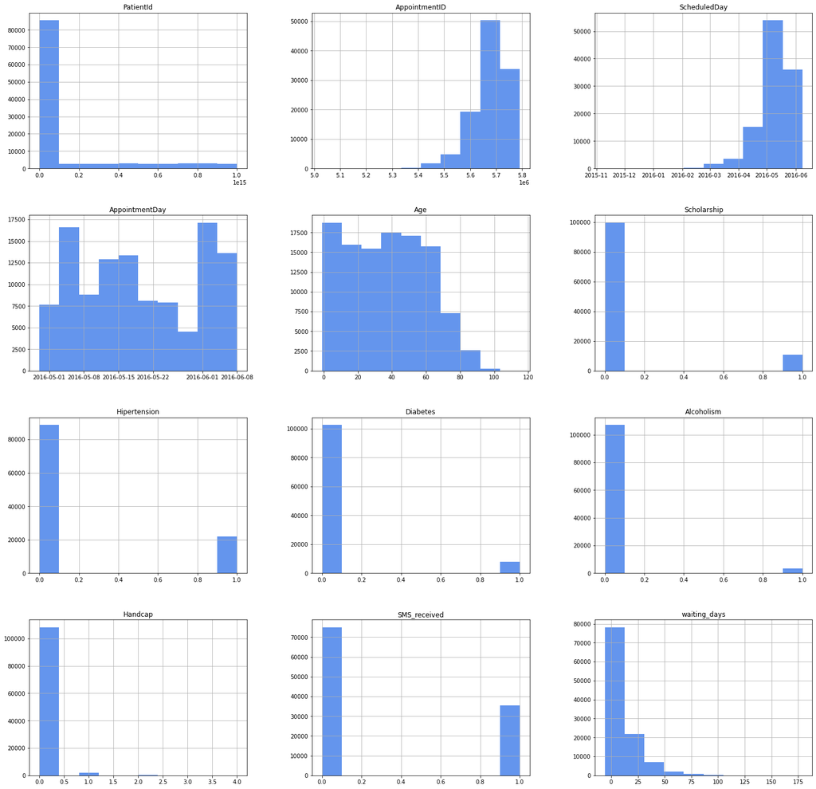

```python
NSA_DF.hist(figsize=(25,25) , color = 'cornflowerblue')
```

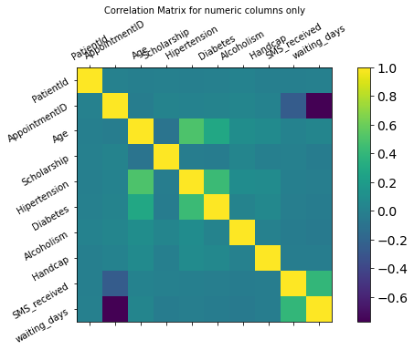

```python
#Make a correlation matrix for numeric columns
#Method (1)
f = plt.figure(figsize=(10, 5))
plt.matshow(NSA_DF.corr(), fignum=f.number)
plt.xticks(range(NSA_DF.select_dtypes(['number']).shape[1]), NSA_DF.select_dtypes(['number']).columns, fontsize=10, rotation=30)
plt.yticks(range(NSA_DF.select_dtypes(['number']).shape[1]), NSA_DF.select_dtypes(['number']).columns, fontsize=10 , rotation=30)
cb = plt.colorbar()
cb.ax.tick_params(labelsize=14)
plt.title('Correlation Matrix for numeric columns only', fontsize=10);
```

```python
#Method (2)
corr = NSA_DF.corr()
corr.style.background_gradient(cmap='coolwarm')
```

|  | PatientId | AppointmentID | Age | Scholarship | Hipertension | Diabetes | Alcoholism | Handcap | SMS_received | waiting_days |
| --- | --- | --- | --- | --- | --- | --- | --- | --- | --- | --- |
| PatientId | 1.000000 | 0.004039 | -0.004139 | -0.002880 | -0.006441 | 0.001605 | 0.011011 | -0.007916 | -0.009749 | -0.001467 |
| AppointmentID | 0.004039 | 1.000000 | -0.019126 | 0.022615 | 0.012752 | 0.022628 | 0.032944 | 0.014106 | -0.256618 | -0.771830 |
| Age | -0.004139 | -0.019126 | 1.000000 | -0.092457 | 0.504586 | 0.292391 | 0.095811 | 0.078033 | 0.012643 | 0.034820 |
| Scholarship | -0.002880 | 0.022615 | -0.092457 | 1.000000 | -0.019729 | -0.024894 | 0.035022 | -0.008586 | 0.001194 | -0.030421 |
| Hipertension | -0.006441 | 0.012752 | 0.504586 | -0.019729 | 1.000000 | 0.433086 | 0.087971 | 0.080083 | -0.006267 | -0.017215 |
| Diabetes | 0.001605 | 0.022628 | 0.292391 | -0.024894 | 0.433086 | 1.000000 | 0.018474 | 0.057530 | -0.014550 | -0.027188 |
| Alcoholism | 0.011011 | 0.032944 | 0.095811 | 0.035022 | 0.087971 | 0.018474 | 1.000000 | 0.004648 | -0.026147 | -0.038519 |
| Handcap | -0.007916 | 0.014106 | 0.078033 | -0.008586 | 0.080083 | 0.057530 | 0.004648 | 1.000000 | -0.024161 | -0.019843 |
| SMS_received | -0.009749 | -0.256618 | 0.012643 | 0.001194 | -0.006267 | -0.014550 | -0.026147 | -0.024161 | 1.000000 | 0.398145 |
| waiting_days | -0.001467 | -0.771830 | 0.034820 | -0.030421 | -0.017215 | -0.027188 | -0.038519 | -0.019843 | 0.398145 | 1.000000 |

```python
# To investigate age
print("Unique Values in Age => {}".format(NSA_DF.Age.unique()))
```

```
Unique Values in Age => [ 62  56   8  76  23  39  21  19  30  29  22  28  54  15  50  40  46   4
  13  65  45  51  32  12  61  38  79  18  63  64  85  59  55  71  49  78
  31  58  27   6   2  11   7   0   3   1  69  68  60  67  36  10  35  20
  26  34  33  16  42   5  47  17  41  44  37  24  66  77  81  70  53  75
  73  52  74  43  89  57  14   9  48  83  72  25  80  87  88  84  82  90
  94  86  91  98  92  96  93  95  97 102 115 100  99  -1]
```

```python
#We have there age below zero which is in correct (Should be deleted) & I will also remove records more than 110
NSA_DF = NSA_DF[(NSA_DF.Age >= 0) & (NSA_DF.Age <= 110)]
NSA_DF.Age.value_counts()
```

```
0      3539
1      2273
52     1746
49     1652
53     1651
       ...
97       11
98        6
100       4
102       2
99        1
Name: Age, Length: 102, dtype: int64
```

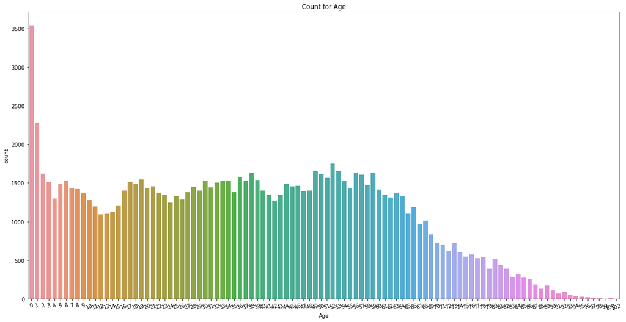

```python
#Now I will make a plot for "How many patients in every Age ?"

plt.figure(figsize=(20,10))
plt.xticks(rotation=20 , size=10)
ax = sns.countplot(x=NSA_DF.Age)
ax.set_title("Count for Age")
plt.show()
```

```python
#I can get unique values using two methodes
```

```python
#Methode (1) to eleminate code duplication by defining a dinamic function which takes any dataframe and return unique values
def get_all_unique_of_NSA_DF(DF):
    DF = NSA_DF
    for col in list(DF):
        print(col)
        print(DF[col].unique())
```

```python
get_all_unique_of_NSA_DF(NSA_DF)
```

```
PatientId
[2.98724998e+13 5.58997777e+14 4.26296230e+12 ... 7.26331493e+13
 9.96997666e+14 1.55766317e+13]
AppointmentID
[5642903 5642503 5642549 ... 5630692 5630323 5629448]
Gender
['F' 'M']
ScheduledDay
['2016-04-29T00:00:00.000000000' '2016-04-27T00:00:00.000000000'
 '2016-04-26T00:00:00.000000000' '2016-04-28T00:00:00.000000000'
 '2016-04-25T00:00:00.000000000' '2016-04-20T00:00:00.000000000'
 '2016-03-31T00:00:00.000000000' '2016-04-19T00:00:00.000000000'
 '2016-04-06T00:00:00.000000000' '2016-04-18T00:00:00.000000000'
 '2016-04-11T00:00:00.000000000' '2016-04-12T00:00:00.000000000'
 '2016-04-15T00:00:00.000000000' '2016-04-01T00:00:00.000000000'
 '2016-04-05T00:00:00.000000000' '2016-04-08T00:00:00.000000000'
 '2016-04-14T00:00:00.000000000' '2016-04-13T00:00:00.000000000'
 '2016-04-07T00:00:00.000000000' '2016-03-17T00:00:00.000000000'
 '2016-03-30T00:00:00.000000000' '2016-03-29T00:00:00.000000000'
 '2016-03-18T00:00:00.000000000' '2016-03-28T00:00:00.000000000'
 '2016-03-04T00:00:00.000000000' '2016-03-15T00:00:00.000000000'
 '2016-03-14T00:00:00.000000000' '2016-03-21T00:00:00.000000000'
 '2016-03-23T00:00:00.000000000' '2016-03-22T00:00:00.000000000'
 '2016-03-16T00:00:00.000000000' '2016-03-10T00:00:00.000000000'
 '2016-02-29T00:00:00.000000000' '2016-03-08T00:00:00.000000000'
 '2016-03-07T00:00:00.000000000' '2016-02-24T00:00:00.000000000'
 '2016-02-22T00:00:00.000000000' '2016-01-29T00:00:00.000000000'
 '2016-02-23T00:00:00.000000000' '2016-02-05T00:00:00.000000000'
 '2016-02-11T00:00:00.000000000' '2016-02-02T00:00:00.000000000'
 '2016-01-05T00:00:00.000000000' '2016-01-11T00:00:00.000000000'
 '2016-02-26T00:00:00.000000000' '2016-02-19T00:00:00.000000000'
 '2016-02-17T00:00:00.000000000' '2016-03-03T00:00:00.000000000'
 '2016-03-02T00:00:00.000000000' '2016-03-09T00:00:00.000000000'
 '2016-03-01T00:00:00.000000000' '2016-03-19T00:00:00.000000000'
 '2016-03-11T00:00:00.000000000' '2016-02-16T00:00:00.000000000'
 '2016-02-25T00:00:00.000000000' '2016-04-09T00:00:00.000000000'
 '2016-05-24T00:00:00.000000000' '2016-05-25T00:00:00.000000000'
 '2016-05-31T00:00:00.000000000' '2016-05-17T00:00:00.000000000'
 '2016-05-30T00:00:00.000000000' '2016-05-12T00:00:00.000000000'
 '2016-05-19T00:00:00.000000000' '2016-05-10T00:00:00.000000000'
```

[output cut: 75 more lines]

```
SMS_received
[0 1]
No-show
['No' 'Yes']
waiting_days
[  0   2   3   1   4   9  29  10  23  11  18  17  14  28  24  21  15  16
  22  43  30  31  42  32  56  45  46  39  37  38  44  50  60  52  53  65
  67  91  66  84  78  87 115 109  63  70  72  57  58  51  59  41  49  73
  64  20  33  34   6  35  36  12  13  40  47   8   5   7  25  26  48  27
  19  61  55  62 176  54  77  69  83  76  89  81 103  79  68  75  85 112
  -1  80  86  98  94 142 155 162 169 104 133 125  96  88  90 151 126 127
 111 119  74  71  82 108 110 102 122 101 105  92  97  93 107  95  -6 139
 132 179 117 146 123]
Name_of_Day
['Friday' 'Wednesday' 'Tuesday' 'Thursday' 'Monday' 'Saturday']
```

```python
# Methode (2)
print("Unique Values in handicap column = {}".format(NSA_DF.Handcap.unique()))
print("Unique Values in Scholarship column = {}".format(NSA_DF.Scholarship.unique()))
print("Unique Values in Hipertension column = {}".format(NSA_DF.Hipertension.unique()))
print("Unique Values in Diabetes column = {}".format(NSA_DF.Diabetes.unique()))
print("Unique Values in SMS_received column = {}".format(NSA_DF.SMS_received.unique()))
print("Unique Values in waiting_days column = {}".format(NSA_DF.waiting_days.unique()))
print("Unique Values in Neighbourhood column = {}".format(NSA_DF.Neighbourhood.unique()))
```

```
Unique Values in handicap column = [0 1 2 3 4]
Unique Values in Scholarship column = [0 1]
Unique Values in Hipertension column = [1 0]
Unique Values in Diabetes column = [0 1]
Unique Values in SMS_received column = [0 1]
Unique Values in waiting_days column = [  0   2   3   1   4   9  29  10  23  11  18  17  14  28  24  21  15  16
  22  43  30  31  42  32  56  45  46  39  37  38  44  50  60  52  53  65
  67  91  66  84  78  87 115 109  63  70  72  57  58  51  59  41  49  73
  64  20  33  34   6  35  36  12  13  40  47   8   5   7  25  26  48  27
  19  61  55  62 176  54  77  69  83  76  89  81 103  79  68  75  85 112
  -1  80  86  98  94 142 155 162 169 104 133 125  96  88  90 151 126 127
 111 119  74  71  82 108 110 102 122 101 105  92  97  93 107  95  -6 139
 132 179 117 146 123]
Unique Values in Neighbourhood column = ['JARDIM DA PENHA' 'MATA DA PRAIA' 'PONTAL DE CAMBURI' 'REPÚBLICA'
 'GOIABEIRAS' 'ANDORINHAS' 'CONQUISTA' 'NOVA PALESTINA' 'DA PENHA'
 'TABUAZEIRO' 'BENTO FERREIRA' 'SÃO PEDRO' 'SANTA MARTHA' 'SÃO CRISTÓVÃO'
 'MARUÍPE' 'GRANDE VITÓRIA' 'SÃO BENEDITO' 'ILHA DAS CAIEIRAS'
 'SANTO ANDRÉ' 'SOLON BORGES' 'BONFIM' 'JARDIM CAMBURI' 'MARIA ORTIZ'
 'JABOUR' 'ANTÔNIO HONÓRIO' 'RESISTÊNCIA' 'ILHA DE SANTA MARIA'
 'JUCUTUQUARA' 'MONTE BELO' 'MÁRIO CYPRESTE' 'SANTO ANTÔNIO' 'BELA VISTA'
 'PRAIA DO SUÁ' 'SANTA HELENA' 'ITARARÉ' 'INHANGUETÁ' 'UNIVERSITÁRIO'
 'SÃO JOSÉ' 'REDENÇÃO' 'SANTA CLARA' 'CENTRO' 'PARQUE MOSCOSO'
 'DO MOSCOSO' 'SANTOS DUMONT' 'CARATOÍRA' 'ARIOVALDO FAVALESSA'
 'ILHA DO FRADE' 'GURIGICA' 'JOANA D´ARC' 'CONSOLAÇÃO' 'PRAIA DO CANTO'
 'BOA VISTA' 'MORADA DE CAMBURI' 'SANTA LUÍZA' 'SANTA LÚCIA'
 'BARRO VERMELHO' 'ESTRELINHA' 'FORTE SÃO JOÃO' 'FONTE GRANDE'
 'ENSEADA DO SUÁ' 'SANTOS REIS' 'PIEDADE' 'JESUS DE NAZARETH'
 'SANTA TEREZA' 'CRUZAMENTO' 'ILHA DO PRÍNCIPE' 'ROMÃO' 'COMDUSA'
 'SANTA CECÍLIA' 'VILA RUBIM' 'DE LOURDES' 'DO QUADRO' 'DO CABRAL' 'HORTO'
 'SEGURANÇA DO LAR' 'ILHA DO BOI' 'FRADINHOS' 'NAZARETH' 'AEROPORTO'
 'ILHAS OCEÂNICAS DE TRINDADE' 'PARQUE INDUSTRIAL']
```

```python
# I have a negative value in waiting day column so I will remove these record
NSA_DF = NSA_DF[(NSA_DF.waiting_days >= 0)]
```

```python
#Inspecting after changing
print("Unique Values in waiting_days column = {}".format(NSA_DF.waiting_days.unique()))
```

```
Unique Values in waiting_days column = [  0   2   3   1   4   9  29  10  23  11  18  17  14  28  24  21  15  16
  22  43  30  31  42  32  56  45  46  39  37  38  44  50  60  52  53  65
  67  91  66  84  78  87 115 109  63  70  72  57  58  51  59  41  49  73
  64  20  33  34   6  35  36  12  13  40  47   8   5   7  25  26  48  27
  19  61  55  62 176  54  77  69  83  76  89  81 103  79  68  75  85 112
  80  86  98  94 142 155 162 169 104 133 125  96  88  90 151 126 127 111
 119  74  71  82 108 110 102 122 101 105  92  97  93 107  95 139 132 179
 117 146 123]
```

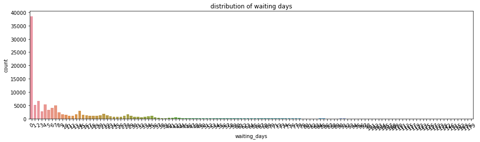

```python
# Now I will see istribution of waiting days
plt.figure(figsize=(16,4))
plt.xticks(rotation=30)
ax = sns.countplot(x=NSA_DF.waiting_days)
ax.set_title("distribution of waiting days")
plt.show()
```

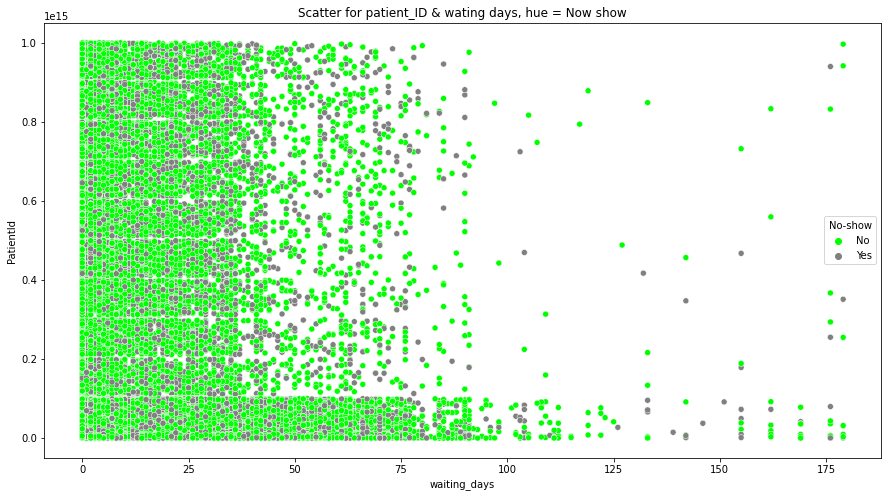

```python
plt.figure(figsize=(15,8))
plt.title("Scatter for patient_ID & wating days, hue = Now show")
hue_colors = {"Yes": "#808080","No": "#00FF00"}
sns.scatterplot(x=NSA_DF.waiting_days,y=NSA_DF.PatientId,data=NSA_DF,hue=NSA_DF['No-show'],palette=hue_colors)
plt.show()
```

```python
# I will see how many patient thier appiontment in the same day
NSA_DF[(NSA_DF.waiting_days== 0)].waiting_days.value_counts()
```

```
0    38561
Name: waiting_days, dtype: int64
```

This gives not good expression about the system that less than 40% of people only will viewed in the same day.

```python
#To know number in each category in Handcap column
NSA_DF.Handcap.value_counts()
```

```
0    108281
1      2036
2       183
3        13
4         3
Name: Handcap, dtype: int64
```

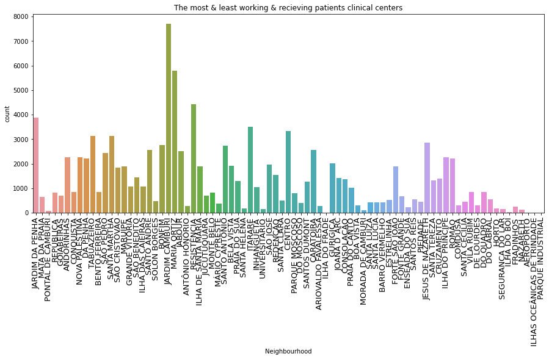

```python
#To view which hospitals or medical centres that will receive patients
#((The most & least working & recieving patients clinical centers))
np.random.seed(136)
l = "1234567890123"
categories = [ l[i:i+5]+" - "+l[i+1:i+6] for i in range(6)]
x = np.random.choice(categories, size=1000, p=np.diff(np.array([0,0.7,2.8,6.5,8.5,9.3,10])/10.))
ds = pd.Series({"Column" : x})
plt.figure(figsize=(15,6))
plt.xticks(rotation=90 , size=13)
ax = sns.countplot(x=NSA_DF.Neighbourhood)
ax.set_title("The most & least working & recieving patients clinical centers")
plt.show()
```

From the figure Jardim camburi & Maria ortiz are recieving the most number of visits.

```python
#Start & End for schedule days, Appointment days

print('Schedule visits started on: {}.'.format(NSA_DF['ScheduledDay'].min()))
print('Schedule visits ended on: {}.'.format(NSA_DF['ScheduledDay'].max()))
print("-*-"*40)
print('Appointments started on: {}.'.format(NSA_DF['AppointmentDay'].min()))
print('Appointments ended on: {}.'.format(NSA_DF['AppointmentDay'].max()))
```

```
Schedule visits started on: 2015-11-10 00:00:00.
Schedule visits ended on: 2016-06-08 00:00:00.
-*--*--*--*--*--*--*--*--*--*--*--*--*--*--*--*--*--*--*--*--*--*--*--*--*--*--*--*--*--*--*--*--*--*--*--*--*--*--*--*-
Appointments started on: 2016-04-29 00:00:00.
Appointments ended on: 2016-06-08 00:00:00.
```

# Questions

After all these analysis & visualization I want answers to my questions: 1-Are there patients with more than one appointment ? 2-How can we predict or make a relation to know if the patient will go to be showed up or not ? 3-Are Age & Gender together have an effect on show / no-show appointments ?

# Exploratory Data Analysis

# Q1) Are there patients with more than one appointment ?

```python
len(NSA_DF.PatientId.value_counts().iloc[0:10])
```

```
10
```

# Q2) How can we predict or make a relation to know if the patient will go to be showed up or not ?

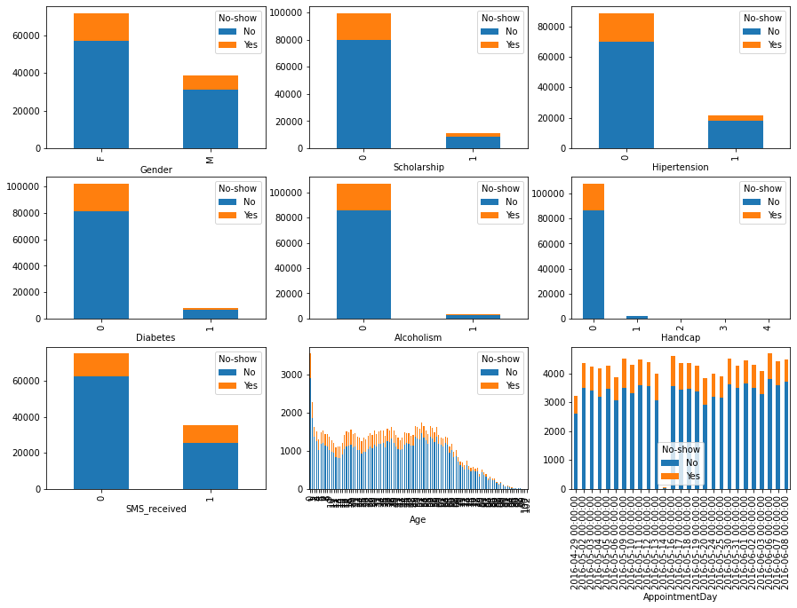

```python
variables = ['Gender', 'Scholarship', 'Hipertension', 'Diabetes', 'Alcoholism', 'Handcap', 'SMS_received', 'Age','AppointmentDay']

fig = plt.figure(figsize=(15, 10))
for i, x in enumerate(variables):
    ax = fig.add_subplot(3, 3, i+1)
    NSA_DF.groupby([x, 'No-show'])[x].count().unstack('No-show').plot(ax=ax, kind='bar', stacked=True)
```

```python
# As some plots in the previous analysis did not give illustrative feedback
showed = NSA_DF['No-show'] == 'No'
not_showed = NSA_DF['No-show'] == 'Yes'
```

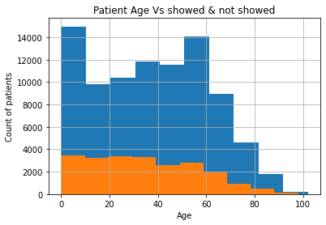

```python
#Here I have complete axis & figure labels as required in the review
#Accorging to age
plt.title('Patient Age Vs showed & not showed')
plt.xlabel('Age')
plt.ylabel('Count of patients')
NSA_DF.Age[showed].hist(alpha=1, bins=10)
NSA_DF.Age[not_showed].hist(alpha=1, bins=10)
```

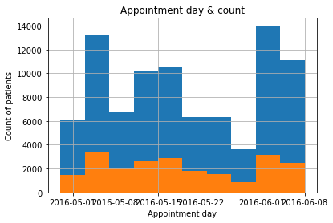

```python
#Here I have complete axis & figure labels as required in the review
#According to appointment day
plt.title('Appointment day & count')
plt.xlabel('Appointment day')
plt.ylabel('Count of patients')
NSA_DF.AppointmentDay[showed].hist(alpha=1, bins=10);
NSA_DF.AppointmentDay[not_showed].hist(alpha=1, bins=10)
```

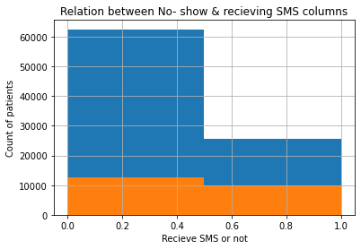

```python
#Here I have complete axis & figure labels as required in the review
#According to appointment day

plt.xlabel('Recieve SMS or not')
plt.ylabel('Count of patients')
plt.title('Relation between No- show & recieving SMS columns')
NSA_DF.SMS_received[showed].hist(alpha=1, bins=2);
NSA_DF.SMS_received[not_showed].hist(alpha=1, bins=2)
```